# Data Divas Midterm

Simintaj Salehpour, Madeline Bumpus, Nazish Atta, Divya Mistry

2025-10-21

### Examining the Relationship Between Demographics, Admission Types, and Clinical Outcomes in New York Inpatients (Niagara County)

## 1. Introduction

**Due:** October 22nd (Wednesday, End of Day)

This R Markdown performs an exploratory data analysis (EDA) for the dataset `Hospital_Inpatient_Discharges.csv`. It contains code, explanation, dataset summary, descriptive statistics, graphical displays, variance/SD measures, normality checks, and initial statistical tests.

## 2. Load dataset

```
## Dataset dimensions: Rows: 21075 Columns: 34
```

```
## Rows: 21,075
## Columns: 34
## $ Health.Service.Area                 <chr> "Western NY", "Western NY", "Weste…
## $ Hospital.County                     <chr> "Niagara", "Niagara", "Niagara", "…
## $ Operating.Certificate.Number        <int> 3101000, 3101000, 3101000, 3101000…
## $ Facility.ID                         <int> 565, 565, 565, 565, 565, 565, 565,…
## $ Facility.Name                       <chr> "Eastern Niagara Hospital - Lockpo…
## $ Age.Group                           <chr> "18 to 29", "18 to 29", "0 to 17",…
## $ Zip.Code...3.digits                 <chr> "140", "140", "140", "140", "140",…
## $ Gender                              <chr> "M", "F", "F", "M", "F", "F", "M",…
## $ Race                                <chr> "White", "White", "White", "White"…
## $ Ethnicity                           <chr> "Not Span/Hispanic", "Not Span/His…
## $ Length.of.Stay                      <chr> "1", "2", "2", "5", "2", "2", "2",…
## $ Type.of.Admission                   <chr> "Emergency", "Emergency", "Newborn…
## $ Patient.Disposition                 <chr> "Home or Self Care", "Home or Self…
```

[output cut: 21 more lines]

## 3. Handle missing value

Here I check if there is a missing value or not. For each column check the missing value.

```
## # A tibble: 34 × 2
##    `column(variable)`           n_missing
##    <chr>                            <int>
##  1 Health.Service.Area                  0
##  2 Hospital.County                      0
##  3 Operating.Certificate.Number         0
##  4 Facility.ID                          0
##  5 Facility.Name                        0
##  6 Age.Group                            0
##  7 Zip.Code...3.digits                  0
##  8 Gender                               0
##  9 Race                                 0
## 10 Ethnicity                            0
## # ℹ 24 more rows
```

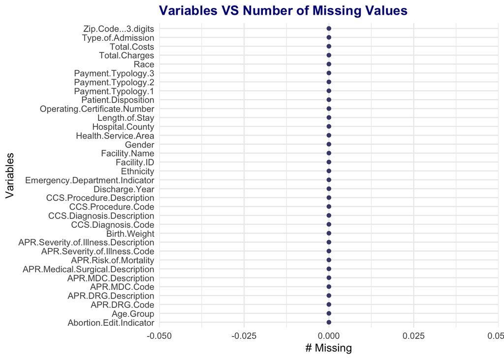

```
## No missing values detected. Dataset is clean.
```

## 4. Remove Duplicates

Here I check to remove duplicates:

```
## Number of duplicate rows: 4
```

## 5. Descriptive statistics

```
## Numeric Columns summary:
```

Data summary

| Name | num_vars |
| --- | --- |
| Number of rows | 21071 |
| Number of columns | 11 |
| _______________________ |  |
| Column type frequency: |  |
| numeric | 11 |
| ________________________ |  |
| Group variables | None |

**Variable type: numeric**

| skim_variable | n_missing | complete_rate | mean | sd | p0 | p25 | p50 | p75 | p100 | hist |
| --- | --- | --- | --- | --- | --- | --- | --- | --- | --- | --- |
| Operating.Certificate.Number | 0 | 1 | 2880548.75 | 579505.37 | 1401014.00 | 3101000.00 | 3102000.00 | 3121001.00 | 3121001.0 | ▁▁▁▁▇ |
| Facility.ID | 0 | 1 | 576.23 | 7.07 | 565.00 | 574.00 | 574.00 | 583.00 | 585.0 | ▅▁▇▃▇ |
| Discharge.Year | 0 | 1 | 2012.00 | 0.00 | 2012.00 | 2012.00 | 2012.00 | 2012.00 | 2012.0 | ▁▁▇▁▁ |
| CCS.Diagnosis.Code | 0 | 1 | 218.95 | 191.22 | 2.00 | 108.00 | 153.00 | 218.00 | 670.0 | ▇▇▁▁▂ |
| CCS.Procedure.Code | 0 | 1 | 96.46 | 88.59 | 0.00 | 0.00 | 86.00 | 202.00 | 231.0 | ▇▂▂▂▆ |
| APR.DRG.Code | 0 | 1 | 406.24 | 245.63 | 4.00 | 198.00 | 321.00 | 640.00 | 952.0 | ▅▇▃▅▂ |
| APR.MDC.Code | 0 | 1 | 10.13 | 6.11 | 1.00 | 5.00 | 8.00 | 15.00 | 25.0 | ▇▇▅▅▁ |
| APR.Severity.of.Illness.Code | 0 | 1 | 1.97 | 0.85 | 1.00 | 1.00 | 2.00 | 2.00 | 4.0 | ▆▇▁▃▁ |
| Birth.Weight | 0 | 1 | 174.99 | 739.64 | 0.00 | 0.00 | 0.00 | 0.00 | 4900.0 | ▇▁▁▁▁ |
| Total.Charges | 0 | 1 | 12421.15 | 13878.88 | 423.98 | 5084.56 | 8267.16 | 14651.49 | 294515.6 | ▇▁▁▁▁ |
| Total.Costs | 0 | 1 | 6607.40 | 7378.03 | 103.31 | 2634.34 | 4378.96 | 7826.79 | 187205.7 | ▇▁▁▁▁ |

```
## Categorical Columns Summary (first 5 columns):
```

```
## Column: Health.Service.Area
## Western NY
##      21071
##
## Column: Hospital.County
## Niagara
##   21071
##
## Column: Facility.Name
##
##        Niagara Falls Memorial Medical Center
##                                         6487
##    Mount St Marys Hospital and Health Center
##                                         5587
## Eastern Niagara Hospital - Lockport Division
##                                         4553
##                    Degraff Memorial Hospital
##                                         2802
##  Eastern Niagara Hospital - Newfane Division
##                                         1642
##
## Column: Age.Group
##
## 70 or Older    50 to 69    30 to 49    18 to 29     0 to 17
##        7523        5974        3852        2369        1353
##
## Column: Zip.Code...3.digits
##
##  143  140  141  142       OOS
## 8077 6436 5261  870  189  160
```

# SMART Question 1

**Did Medicare patients have, on average, at least 15% longer hospital stays than Private Insurance patients in Niagara County (2012)?**

```
## Step 1: Loading the dataset
```

```
## Dataset loaded successfully with 21075 rows and 34 columns.
```

```
## Step 2: Handling missing values
```

```
## No missing values detected. Dataset is clean.
```

```
## Removing duplicate rows if any...
```

```
## Duplicates removed. Data ready for analysis.
```

```
## Step 3: Categorizing insurance types and converting stay length to numeric
```

```
## Insurance groups categorized and outliers removed.
```

```
## Step 4: Computing descriptive statistics
```

```
## # A tibble: 2 × 4
##   Insurance_Group   mean_LOS sd_LOS count
##   <chr>                <dbl>  <dbl> <int>
## 1 Medicare              4.62   3.05 10536
## 2 Private Insurance     2.64   1.50  4031
```

```
##
## Descriptive statistics calculated for each insurance group.
```

```
## Step 5: Computing ratio of means (Medicare vs. Private)
```

```
## Mean Medicare LOS is 1.75 times that of Private Insurance.
```

```
## Step 6: Running one-sided t-test
```

```
##
##  Welch Two Sample t-test
##
## data:  Length.of.Stay by Insurance_Group
## t = 52.356, df = 13736, p-value < 2.2e-16
## alternative hypothesis: true difference in means between group Medicare and group Private Insurance is greater than 0
## 95 percent confidence interval:
##  1.923577      Inf
## sample estimates:
##          mean in group Medicare mean in group Private Insurance
##                        4.624525                        2.638551
```

```
## T-test completed.
```

```
## Step 7: Interpreting results
```

```
## Medicare patients stayed significantly longer on average.
## The mean length of stay for Medicare patients (4.62 days) was about 75.3% longer than for Private Insurance patients (2.64 days), with p = 0. This difference is statistically significant (p < 0.05).
```

```
## Step 8: Visualizing average hospital stays by insurance type
```

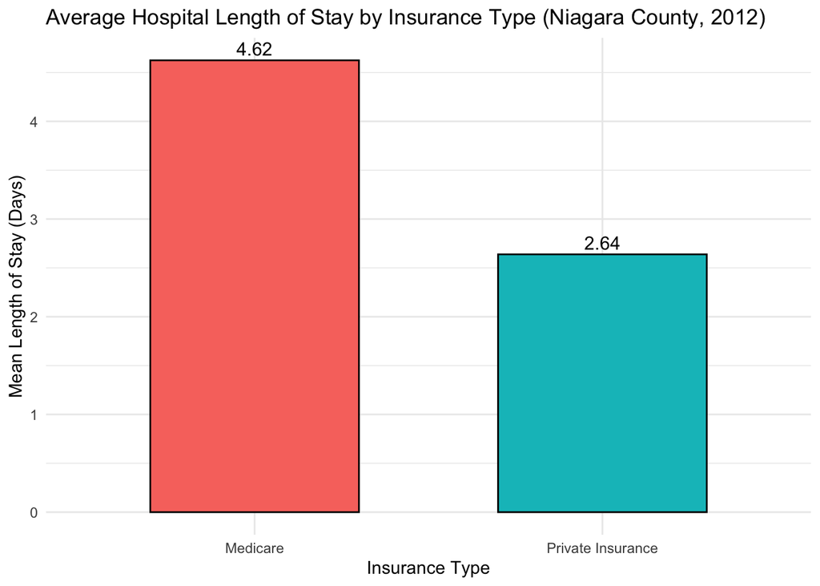

# SMART Question 2:

**Can we analyze 2012 hospital records to quantify whether Medicaid patients’ total hospital costs were 10% higher than patients with Private Insurance?**

```
## Removing outliers for Total.Costs:
```

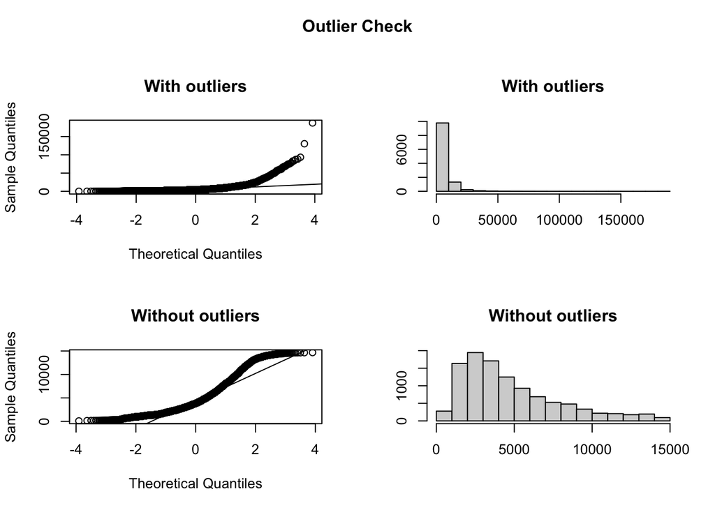

```
## Outliers identified: 838
## Proportion (%) of outliers: 7.8
## Mean of the outliers: 24940.88
## Mean without removing outliers: 6217.79
## Mean if we remove outliers: 4748.97
## Outliers successfully removed
```

```
## Removing outliers for Total.Charges:
```

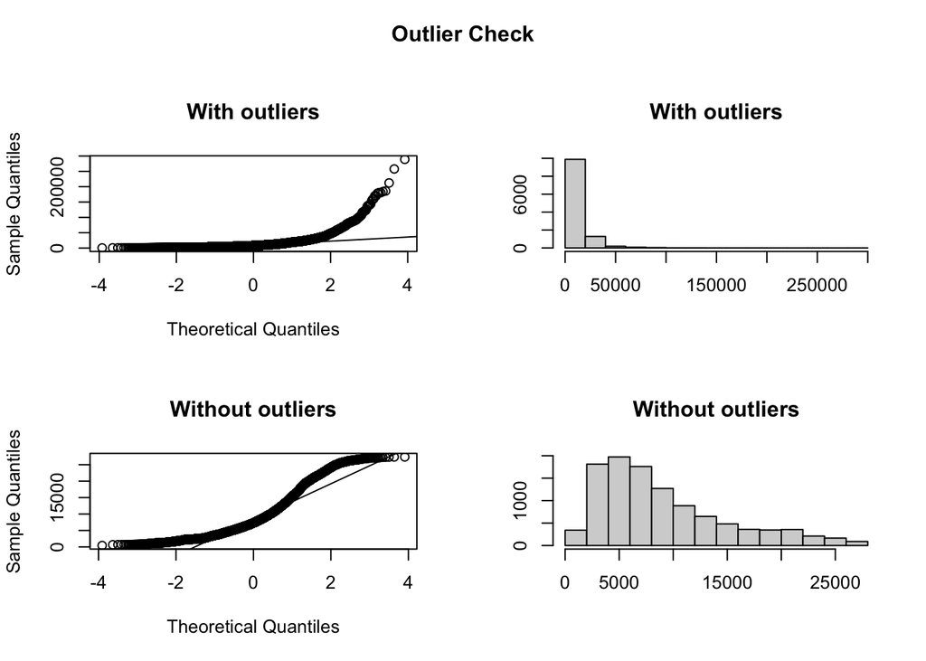

```
## Outliers identified: 815
## Proportion (%) of outliers: 7.6
## Mean of the outliers: 47831.9
## Mean without removing outliers: 11748.56
## Mean if we remove outliers: 9001.44
## Outliers successfully removed
```

```
## Apply T-test on Average Total Hospital Costs by Insurance Type:
```

```
##
##  Welch Two Sample t-test
##
## data:  Total.Costs by Insurance_Use
## t = -9.6933, df = 8936.2, p-value < 2.2e-16
## alternative hypothesis: true difference in means between group Medicaid and group Private Insurance is not equal to 0
## 95 percent confidence interval:
##  -729.8429 -484.3110
## sample estimates:
##          mean in group Medicaid mean in group Private Insurance
##                        4503.687                        5110.763
```

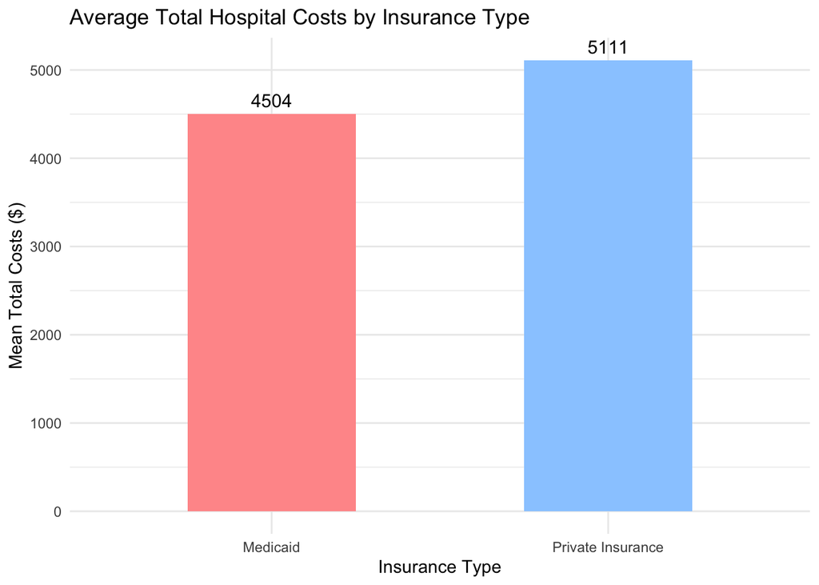

```
## Medicaid patients' total hospital costs are approximately 11.88 % lower than Private Insurance.
## Medicaid patients had lower mean total hospital costs ($4503.69) than Private Insurance patients ($5110.76), approximately 11.88% difference. The difference was statistically significant (t = -9.69, df = 8936.2, p < 0.001).
```

```
## Extra part: Here we check the total_charge based on insurance types:
```

```
## Apply T-test on Average Total Hospital charge by Insurance Type:
```

```
##
##  Welch Two Sample t-test
##
## data:  Total.Charges by Insurance_Use
## t = -5.1892, df = 9330.6, p-value = 2.157e-07
## alternative hypothesis: true difference in means between group Medicaid and group Private Insurance is not equal to 0
## 95 percent confidence interval:
##  -834.7923 -377.0254
## sample estimates:
##          mean in group Medicaid mean in group Private Insurance
##                        8755.110                        9361.019
```

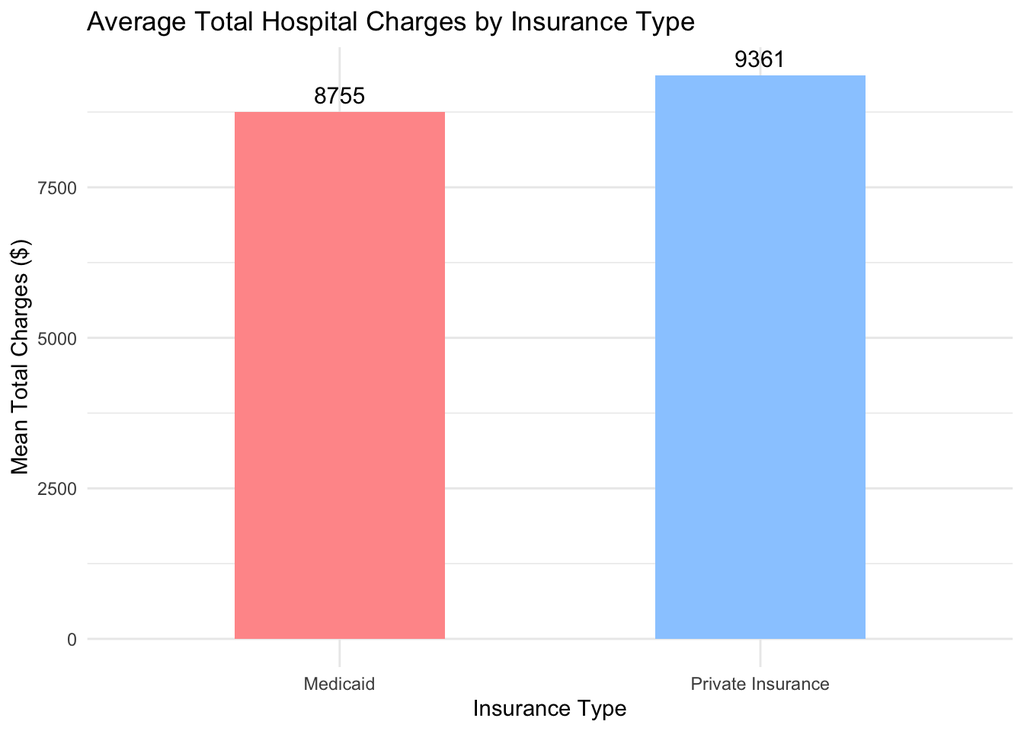

```
## Medicaid patients' total hospital charges are approximately 6.47 % lower than Private Insurance.
## Medicaid patients had lower mean total hospital charges ($8755.11) than Private Insurance patients ($9361.02), approximately 6.47% difference. The difference was statistically significant (t = -5.19, df = 9330.6, p < 0.001).
```

# SMART Question 3

**Did elderly patients (70+) stay 25% longer than patients aged 30–49 in 2012?**

2012 21071

```
0 to 17    18 to 29    30 to 49    50 to 69 70 or Older
   1353        2369        3852        5974        7523
```

Age buckets created. Here are the counts:

Percent longer stay for 70+ vs 30–49: 4.99 % Count of observations: 70+ group: 7523 30-49 group: 3852 Number of observations: 70+ group: 7523 30–49 group: 3852

```
Welch Two Sample t-test
```

data: g70 and g30 t = 2.0141, df = 5976.3, p-value = 0.04404 alternative hypothesis: true difference in means is not equal to 0 95 percent confidence interval: 0.007037163 0.519988094 sample estimates: mean of x mean of y 5.547521 5.284008

Unique Age Groups: [1] “18 to 29” “0 to 17” “70 or Older” “30 to 49” “50 to 69”

Groups after filtering:

30 to 49 70 or Older 3852 7523 # A tibble: 2 × 2 Age.Group mean_LOS 1 30 to 49 5.28 2 70 or Older 5.55

Elderly / 30–49 ratio = 1.05

Welch Two Sample t-test:

```
Welch Two Sample t-test
```

data: Length.of.Stay by Age.Group t = -2.0141, df = 5976.3, p-value = 0.978 alternative hypothesis: true difference in means between group 30 to 49 and group 70 or Older is greater than 0 95 percent confidence interval: -0.4787434 Inf sample estimates: mean in group 30 to 49 mean in group 70 or Older 5.284008 5.547521

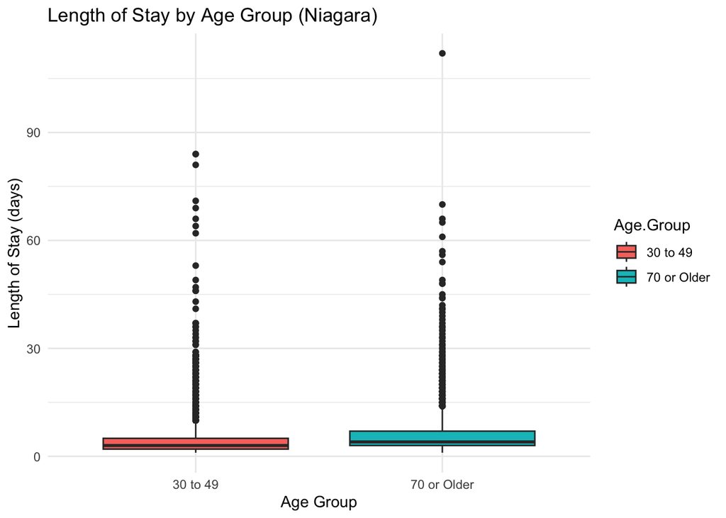

# SMART Question 4

**Did emergency admissions result in 30% longer hospital stays than elective ones in 2012?**

```
##
## Purpose:
## Analyze the difference in Length of Stay (LOS) between Emergency and Elective admissions
## using SPARCS 2012 Niagara County data.
##
## Why it matters:
## Hospital efficiency and patient-flow optimization rely on understanding LOS variation.
```

| los | admission_type | age_group | gender |
| --- | --- | --- | --- |
| 1 | Emergency | 18 to 29 | M |
| 2 | Emergency | 18 to 29 | F |
| 5 | Emergency | 70 or Older | M |
| 2 | Elective | 18 to 29 | F |
| 2 | Elective | 0 to 17 | F |
| 2 | Elective | 70 or Older | M |

```
##       los               admission_type        age_group    gender
##  Min.   :  1.00   Elective     : 4145   0 to 17    : 196   F:11133
##  1st Qu.:  2.00   Emergency    :15083   18 to 29   :2161   M: 8095
##  Median :  3.00   Newborn      :    0   30 to 49   :3662
##  Mean   :  5.41   Not Available:    0   50 to 69   :5826
##  3rd Qu.:  6.00   Urgent       :    0   70 or Older:7383
##  Max.   :112.00
```

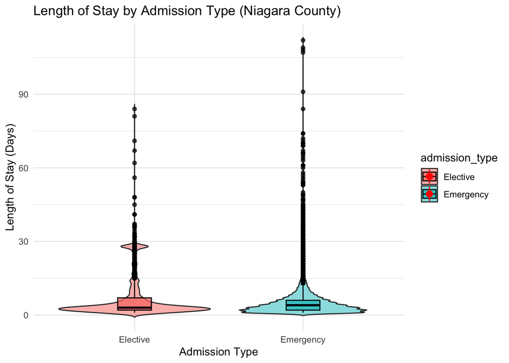

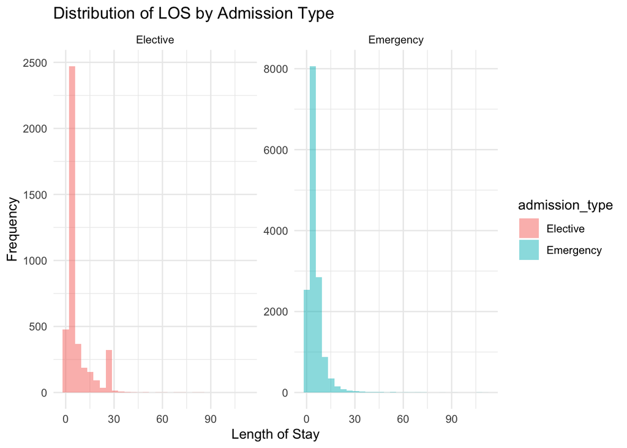

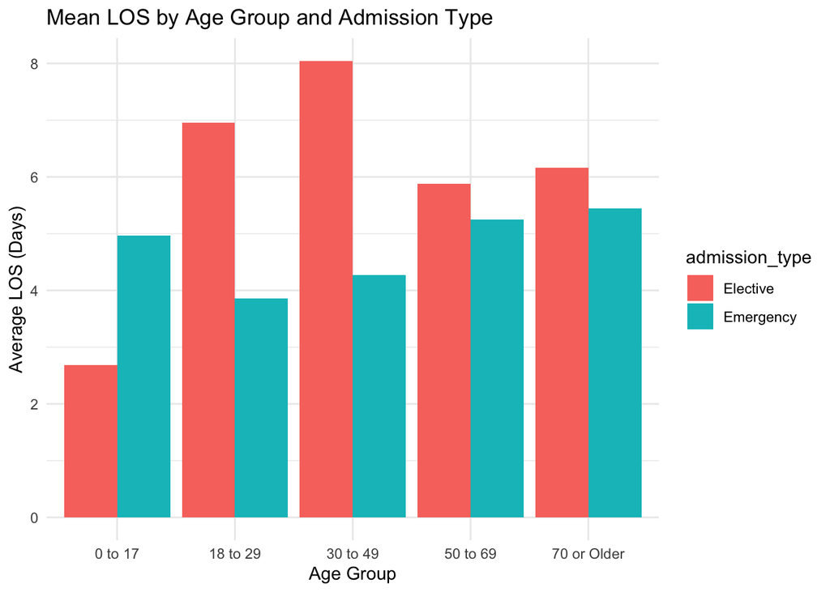

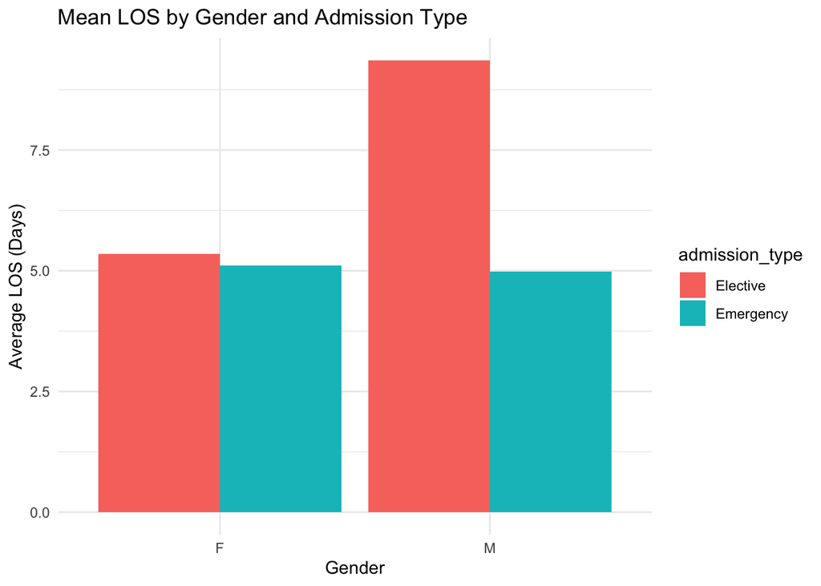

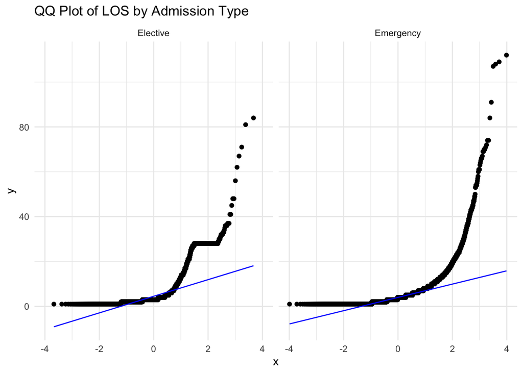

```
## Levene's Test for Homogeneity of Variance (center = median)
##          Df F value    Pr(>F)
## group     1  246.15 < 2.2e-16 ***
##       19226
## ---
## Signif. codes:  0 '***' 0.001 '**' 0.01 '*' 0.05 '.' 0.1 ' ' 1
```

```
## [1] Emergency Elective
## Levels: Elective Emergency
```

```
##
##  Welch Two Sample t-test
##
## data:  los by admission_type
## t = 12.229, df = 5290.4, p-value < 2.2e-16
## alternative hypothesis: true difference in means between group Elective and group Emergency is not equal to 0
## 95 percent confidence interval:
##  1.405815 1.942575
## sample estimates:
##  mean in group Elective mean in group Emergency
##                6.723522                5.049327
```

```
## # A tibble: 2 × 2
##   admission_type mean_los
##   <fct>             <dbl>
## 1 Elective           6.72
## 2 Emergency          5.05
```

```
## Emergency stays are 24.9 % SHORTER than Elective stays.
```

```
## Observed mean ratio (Emergency/Elective): 0.751
```

```
## Cohen's d |       95% CI
## ------------------------
## 0.26      | [0.23, 0.30]
##
## - Estimated using pooled SD.
```

```
##
##  Welch Two Sample t-test
##
## data:  log_los by admission_type
## t = 8.2019, df = 5730.7, p-value = 2.894e-16
## alternative hypothesis: true difference in means between group Elective and group Emergency is not equal to 0
## 95 percent confidence interval:
##  0.08261313 0.13450816
## sample estimates:
##  mean in group Elective mean in group Emergency
##                1.673387                1.564826
```

```
##
## Call:
## lm(formula = los ~ admission_type + age_group + gender, data = dfq)
##
## Residuals:
##     Min      1Q  Median      3Q     Max
##  -6.615  -3.411  -1.846   0.994 106.994
##
## Coefficients:
##                         Estimate Std. Error t value Pr(>|t|)
## (Intercept)              5.61938    0.46468  12.093  < 2e-16 ***
## admission_typeEmergency -1.89652    0.11518 -16.466  < 2e-16 ***
## age_group18 to 29        0.41086    0.47567   0.864   0.3877
## age_group30 to 49        0.79208    0.46696   1.696   0.0899 .
## age_group50 to 69        0.95356    0.46249   2.062   0.0392 *
## age_group70 or Older     1.28267    0.46099   2.782   0.0054 **
## genderM                  0.71278    0.09367   7.609 2.89e-14 ***
## ---
## Signif. codes:  0 '***' 0.001 '**' 0.01 '*' 0.05 '.' 0.1 ' ' 1
##
## Residual standard error: 6.368 on 19221 degrees of freedom
## Multiple R-squared:  0.01648,    Adjusted R-squared:  0.01617
## F-statistic: 53.67 on 6 and 19221 DF,  p-value: < 2.2e-16
```

[output not shown]